# Глава 2. Материалы и методы

Турбин К.О., Акулаев А.А., Апанасенко А.О., Повалий А.А.

2023-07-07

# ГЛАВА 2. МАТЕРИАЛЫ И МЕТОДЫ

## 2.1 Общая структура настоящего исследования

Клиническая часть состояла из четырех этапов: Первый этпап был ретроспективным клиническим, второй этап был экспериментальным третий этпап был клинико-экспериментальным клиническим и четвертый этап был проспективным клиническим. Все исследование было выполнено на основании изучения клинических и рентгенологических данных пациентов с НСП ДМЭ ЛК ДМЭ ЛК , проходивших лечение в травматологическом отделении №2 Клиники высоких медицинских технологий СПбГУ с апреля 2018 года по сентябрь 2022 Всего было исследовано 109 пациентов и 34 человека с не поврежденной конечностью. Всего в исследовании было 5 групп. Схема исследования представлена на рисунке №2.1.

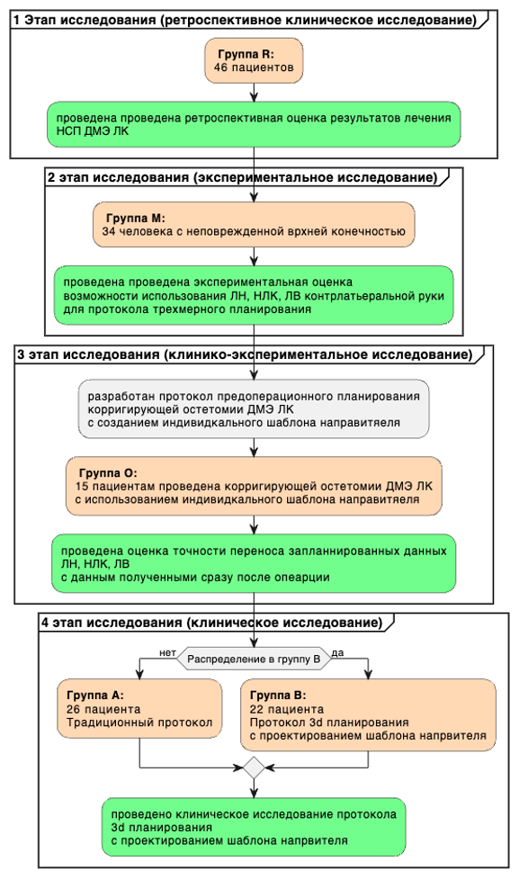

Рисунок №2.1. Общая схема настоящего диссертационного исследования На первом этапе было исследовано 46 пациентов. Эту часть исследования можно охарактеризовать как ретроспективное кагортное исследование Была сформирована группа R (R- от английского ‘retrospective’ - ретроспективный). Регистрировались и оценивались такие показатели анамнеза, инструментальные данные и данные анкетирования (более подробно в разделе ’ 2.1.5 Регистрируемые данные и класификаторы ’) По выявленным показателям проводилась оценка качества коррегирующей остеотомии ДМЭ ЛК при неправильом сращениии ДМЭ ЛК

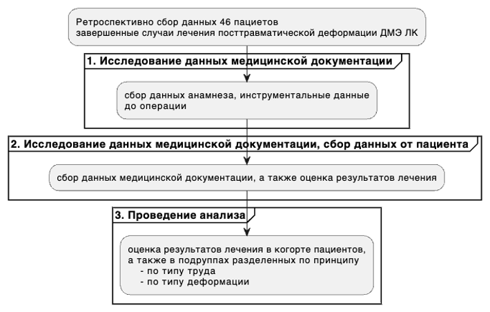

Рисунок №2.2. Схема первого этапа исследования На втором этапе было исследовано 34 человека с неповрежденной врхней конечностью. Была сформирована группа M (M- от английского ‘measurement’ - измерение). Участникам исследования проводиласть мультиспиральная компьютерная томография обеих лучезапястных суставов (МСКТ, подробное описание исследование указано в разделе « 2.1.2 Методы лучевой диагности и оценка референтных значений » текущей главы) Регистрировались и оценивались такие инструментальные данные (более подробно в разделе ’ 2.1.5 Регистрируемые данные и класификаторы ‘) Далее проводилось сравнение противоположных конечностей с целью решения вопросв ’Можно ли использовать показатели противоположной руки для моделирования коррегирующей остеотомии?’

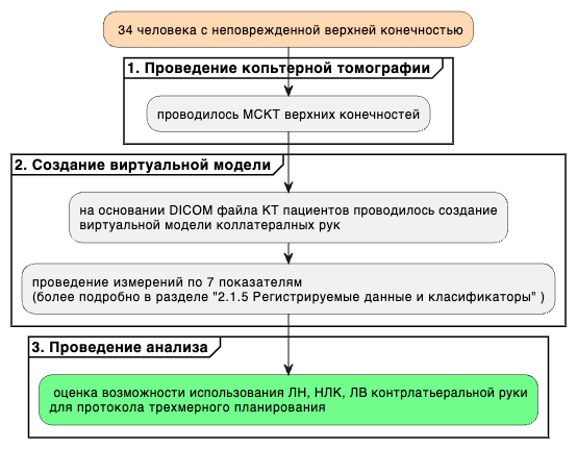

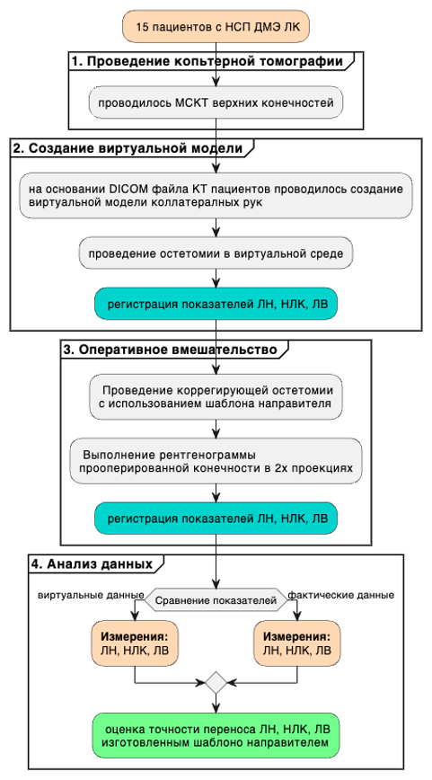

Рисунок №2.4. Схема третьего этапа исследования На четвертом этапе было исследовано 48 пациентов. Была проведена разработка протоола пердоперационного планирования с созданием шаблона направителя Пациенты были разделены на 2 группы: A и B - принцип названия взят как порядковые буквы латинского алфавита. Группа A была контрольной и в нее вошли 26 пациенов. В этой группе протокол лечения был по традиционной методике. Во вторую группу вошли 22 пациенов. Это группа была исследуемой. Пациенты проходили лечение с применением разработанного протокола трехмерного планирования с применением шаблона направителя. Данные, регистрируемые на этом этапе подробно в описаны в разделе разделе ’ 2.1.5 Регистрируемые данные и класификаторы ’) Это этап стал завершающим настоящее диссертационное исслеование

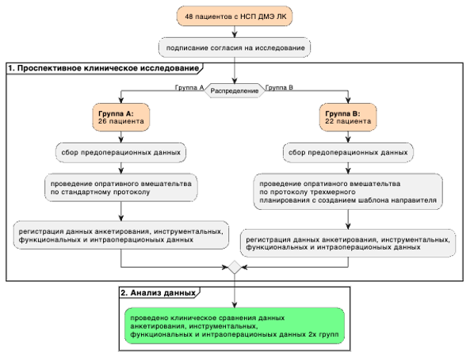

Рисунок №2.5. Схема четвертого этапа исследования ### 2.1.1 Критерии включения и исключения

Критериями включения для этапов исследования, где исследемыми были пациенты с НСП ДМЭ ЛК заболевание должно было проявляться болью в запястье, деформацией и ограничением объема движений. Диагноз посттравматической деформации НСП ДМЭ ЛК устанавливался на основании полного сбора анамнеза и данных рентгенологического исследования лучезапястного сустава в прямой и боковой проекциях. Все пациенты перенесли внесуставной перелом, первоначально была выполнена закрытая ручная репозиция отломков с последующей гипсовой иммобилизацией в среднем на 6-8 недель. Хирургическое лечение этим пациентам ранее не проводилось.

Критериями включения для этапа исследования, где исследемыми были участники без патологии было отсутвие повреждения ДМЭ, предплечья и кисти в анамнезе

Критериями исключения были:

• сахарный диабет

• носительство вируса гепатита В или С

• специфический артрит

• хроническая почечная недостаточность (креатинин >200 мкмоль/л)

• язвенная болезнь

• хроническое применение глюкокортикойдов

• иммунодепрессантов, иммуномодулирующих препаратов, опиойдов.